# Non-KS Drug Target Integration: Strategy Exploration

Connecting GPCRs, NRs, and orphan kinases to the KS network

Author

Chinmaya Joisa

Published

April 20, 2026

```r
suppressPackageStartupMessages({
  library(data.table)
  library(tidyverse)
  library(fst)
  library(here)
  library(scales)
  library(ggpubr)
  library(patchwork)
  library(igraph)
  library(DT)
  library(clusterProfiler)
  library(org.Hs.eg.db)
  library(OmnipathR)
})
```

# Background

The 114 missing targets represent a distinct biology: GPCRs, nuclear receptors, receptor kinases, and metabolic off-targets. This document explores **three smarter integration strategies**:

| Strategy | Approach | Mechanism | Expected Coverage |
| --- | --- | --- | --- |
| **A** | HIPPIE 1-hop full expansion | All high-confidence PPI edges to KS network | Most targets → degree ≥ 2 |
| **B** | OmniPath directed signaling | Curated stimulation/inhibition edges | Subset with high biological fidelity |
| **C** | OmniPath + HIPPIE fallback | B first, A for remainder | Maximum coverage + quality |

# Load Data

```r
# v2 network (with old brute-force HIPPIE layer)
network_v2 <- read_csv(here("results/extended_kinome_network_summary_v2.csv"),
                       show_col_types = FALSE) %>%
  mutate(Protein1_entrez = as.character(Protein1_entrez),
         Protein2_entrez = as.character(Protein2_entrez))

# KS backbone (excluding old brute-force layer)
ks_backbone <- network_v2 %>%
  dplyr::filter(Sources != "HIPPIE_DrugTarget")

all_ks_nodes_sym   <- union(ks_backbone$Protein1, ks_backbone$Protein2)
all_ks_nodes_entrez <- union(ks_backbone$Protein1_entrez, ks_backbone$Protein2_entrez)

# Drug target panel
drug_targets <- read.fst(here("data/kinome_profiling_novartis_evebio_combined.fst")) %>%
  as_tibble() %>%
  distinct(target, target_entrez_id) %>%
  mutate(target_entrez_id = as.character(target_entrez_id))

# Isolated 114 targets (old brute-force)
hippie_dt_old <- network_v2 %>% dplyr::filter(Sources == "HIPPIE_DrugTarget")
isolated_entrez <- unique(hippie_dt_old$Protein2_entrez)
isolated_genes  <- unique(hippie_dt_old$Protein2)

cat("KS backbone edges:       ", nrow(ks_backbone), "\n")
```

```
KS backbone edges:        60941
```

```r
cat("KS backbone nodes:       ", length(all_ks_nodes_sym), "\n")
```

```
KS backbone nodes:        4802
```

```r
cat("Total drug targets:      ", nrow(drug_targets), "\n")
```

```
Total drug targets:       654
```

```r
cat("Isolated targets (old):  ", length(isolated_entrez), "\n")
```

```
Isolated targets (old):   114
```

```r
# Drug targets not in KS backbone (excluding HIPPIE BF layer)
missing_from_ks <- drug_targets %>%
  dplyr::filter(!target_entrez_id %in% all_ks_nodes_entrez)

cat("Missing from KS backbone:", nrow(missing_from_ks), "\n")
```

```
Missing from KS backbone: 158
```

# Who Are the 114 Missing Targets?

```r
# GO Molecular Function
go_mf <- enrichGO(gene = isolated_entrez,
                  OrgDb = org.Hs.eg.db, ont = "MF",
                  pAdjustMethod = "BH", pvalueCutoff = 0.1,
                  readable = TRUE)

go_df <- as.data.frame(go_mf) %>%
  dplyr::select(Description, Count, GeneRatio, p.adjust) %>%
  head(20)

cat("=== GO Molecular Function ===\n")
```

```
=== GO Molecular Function ===
```

```r
print(go_df)
```

```
                                               Description Count GeneRatio
GO:0008227       G protein-coupled amine receptor activity    10    10/114
GO:0042562                                 hormone binding    12    12/114
GO:0008528     G protein-coupled peptide receptor activity    13    13/114
GO:0001653                       peptide receptor activity    13    13/114
GO:0004674        protein serine/threonine kinase activity    20    20/114
GO:0030594              neurotransmitter receptor activity    10    10/114
GO:0106310                  protein serine kinase activity    16    16/114
GO:1901338                           catecholamine binding     5     5/114
GO:0004993   G protein-coupled serotonin receptor activity     5     5/114
GO:0017046                         peptide hormone binding     7     7/114
GO:0004879                       nuclear receptor activity     7     7/114
GO:0098531  ligand-modulated transcription factor activity     7     7/114
GO:0008188                  neuropeptide receptor activity     6     6/114
GO:0050660             flavin adenine dinucleotide binding     7     7/114
GO:0098960 postsynaptic neurotransmitter receptor activity     6     6/114
GO:0099589                     serotonin receptor activity     4     4/114
GO:0019199  transmembrane receptor protein kinase activity     6     6/114
GO:0033218                                   amide binding     9     9/114
GO:0003707               nuclear steroid receptor activity     4     4/114
GO:0004935                    adrenergic receptor activity     3     3/114
               p.adjust
GO:0008227 1.216993e-11
GO:0042562 5.588540e-11
GO:0008528 5.588540e-11
GO:0001653 7.753039e-11
GO:0004674 9.014088e-11
GO:0030594 1.711668e-08
GO:0106310 2.493015e-08
GO:1901338 1.959372e-07
GO:0004993 2.816434e-07
GO:0017046 7.390156e-07
GO:0004879 1.653976e-06
GO:0098531 1.707792e-06
GO:0008188 1.672945e-05
GO:0050660 1.787393e-05
GO:0098960 7.839461e-05
GO:0099589 7.839461e-05
GO:0019199 1.361672e-04
GO:0033218 2.859955e-04
GO:0003707 2.878510e-04
GO:0004935 3.233931e-04
```

```r
# KEGG pathways
kegg <- enrichKEGG(gene = isolated_entrez, organism = 'hsa', pvalueCutoff = 0.1)
kegg_df <- as.data.frame(kegg) %>%
  dplyr::select(Description, Count, GeneRatio, p.adjust)
cat("\n=== KEGG Pathways ===\n")
```

```
=== KEGG Pathways ===
```

```r
print(kegg_df)
```

```
                                     Description Count GeneRatio     p.adjust
hsa04080 Neuroactive ligand-receptor interaction    39     39/86 3.224554e-30
hsa04082            Neuroactive ligand signaling    18     18/86 1.156827e-11
hsa04081                       Hormone signaling    14     14/86 4.941135e-07
hsa04020               Calcium signaling pathway    12     12/86 1.180859e-04
hsa04024                  cAMP signaling pathway    10     10/86 1.176201e-03
hsa04022              cGMP-PKG signaling pathway     7      7/86 2.022444e-02
hsa04742                      Taste transduction     5      5/86 2.438380e-02
```

```r
# Classify targets by functional category
sym_map <- bitr(isolated_entrez,
                fromType = "ENTREZID", toType = c("SYMBOL", "GENENAME"),
                OrgDb = org.Hs.eg.db, drop = TRUE)

target_class <- sym_map %>%
  dplyr::mutate(
    category = case_when(
      grepl("G protein-coupled receptor|adrenergic|serotonin|dopamine|histamine|muscarinic|opioid|neuropeptide|adenosine|cannabinoid|chemokine|galanin|GPCR|purinergic|formyl|melanocortin|orexin|angiotensin|melatonin", GENENAME, ignore.case=TRUE) ~ "GPCR",
      grepl("nuclear receptor|retinoid|steroid|thyroid|peroxisome|retinoic", GENENAME, ignore.case=TRUE) ~ "Nuclear Receptor",
      grepl("kinase", GENENAME, ignore.case=TRUE) ~ "Kinase/Kinase-like",
      grepl("transporter|channel|pump|exchanger|ATPase|solute carrier", GENENAME, ignore.case=TRUE) ~ "Transporter/Channel",
      grepl("dehydrogenase|oxidase|synthetase|transferase|isomerase|reductase", GENENAME, ignore.case=TRUE) ~ "Metabolic Enzyme",
      TRUE ~ "Other"
    )
  )

cat("\n=== Target classification ===\n")
```

```
=== Target classification ===
```

```r
target_class %>% count(category, sort = TRUE) %>% print()
```

```
             category  n
1               Other 48
2  Kinase/Kinase-like 28
3                GPCR 18
4    Metabolic Enzyme 10
5    Nuclear Receptor  6
6 Transporter/Channel  4
```

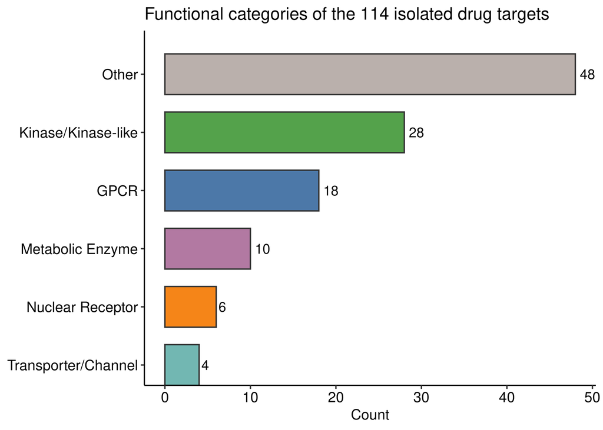

```r
target_class_counts <- target_class %>% count(category) %>%
  mutate(category = fct_reorder(category, n))

p_target_class <- ggplot(target_class_counts, aes(x = category, y = n, fill = category)) +
  geom_col(color = "grey20", width = 0.7, show.legend = FALSE) +
  geom_text(aes(label = n), hjust = -0.3, size = 4) +
  scale_fill_manual(values = c(
    "GPCR"              = "#4C78A8",
    "Nuclear Receptor"  = "#F58518",
    "Kinase/Kinase-like" = "#54A24B",
    "Transporter/Channel" = "#72B7B2",
    "Metabolic Enzyme"  = "#B279A2",
    "Other"             = "#BAB0AC"
  )) +
  scale_x_discrete(expand = expansion(mult = c(0.05, 0.15))) +
  coord_flip() +
  labs(x = NULL, y = "Count",
       title = "Functional categories of the 114 isolated drug targets") +
  theme_pubr()

p_target_class
```

# Load HIPPIE

```r
hippie <- fread(
  here("data/hippie_current.txt"),
  col.names = c("Gene1", "Entrez1", "Gene2", "Entrez2", "Score", "Metadata"),
  colClasses = list(character = c("Entrez1", "Entrez2"))
)

confidence_cutoff <- quantile(hippie$Score, 0.75, na.rm = TRUE)
hippie_hc <- hippie[Score > confidence_cutoff]

cat("HIPPIE high-confidence edges:", nrow(hippie_hc), "\n")
```

```
HIPPIE high-confidence edges: 165236
```

```r
cat("Confidence cutoff (75th pctile):", round(confidence_cutoff, 3), "\n")
```

```
Confidence cutoff (75th pctile): 0.72
```

# Strategy A: HIPPIE 1-Hop Full Expansion

**Rationale:** Instead of the single best-scoring HIPPIE edge, add ALL high-confidence HIPPIE edges connecting each missing target to proteins already in the KS network. This transforms degree-1 isolated nodes into locally clustered subgraphs.

```r
# Find ALL high-confidence HIPPIE edges from isolated targets to KS network nodes
hippie_a <- hippie_hc %>%
  dplyr::filter(
    (Entrez1 %in% isolated_entrez & Entrez2 %in% all_ks_nodes_entrez) |
    (Entrez2 %in% isolated_entrez & Entrez1 %in% all_ks_nodes_entrez)
  ) %>%
  dplyr::mutate(
    isolated_node  = if_else(Entrez1 %in% isolated_entrez, Entrez1, Entrez2),
    ks_node_entrez = if_else(Entrez1 %in% isolated_entrez, Entrez2, Entrez1),
    ks_node_gene   = if_else(Entrez1 %in% isolated_entrez, Gene2, Gene1),
    iso_gene       = if_else(Entrez1 %in% isolated_entrez, Gene1, Gene2)
  ) %>%
  distinct(isolated_node, ks_node_entrez, ks_node_gene, iso_gene, Score)

cat("=== Strategy A: HIPPIE 1-hop full expansion ===\n\n")
```

```
=== Strategy A: HIPPIE 1-hop full expansion ===
```

```r
cat("Total edges (to KS network):", nrow(hippie_a), "\n")
```

```
Total edges (to KS network): 1039
```

```r
cat("Isolated targets covered:   ", n_distinct(hippie_a$isolated_node), "/ 114\n\n")
```

```
Isolated targets covered:    114 / 114
```

```r
# Degree distribution per target
strat_a_degree <- hippie_a %>%
  count(isolated_node, iso_gene) %>%
  dplyr::rename(degree = n)

cat("Degree distribution (# KS-connected edges per target):\n")
```

```
Degree distribution (# KS-connected edges per target):
```

```r
summary(strat_a_degree$degree) %>% print()
```

```
   Min. 1st Qu.  Median    Mean 3rd Qu.    Max.
  1.000   2.000   6.000   9.114  12.000  67.000
```

```r
cat("\nTargets with degree 1 (still isolated):  ", sum(strat_a_degree$degree == 1), "\n")
```

```
Targets with degree 1 (still isolated):   16
```

```r
cat("Targets with degree 2-5:                 ", sum(strat_a_degree$degree >= 2 & strat_a_degree$degree <= 5), "\n")
```

```
Targets with degree 2-5:                  37
```

```r
cat("Targets with degree 6+:                  ", sum(strat_a_degree$degree >= 6), "\n")
```

```
Targets with degree 6+:                   61
```

```r
cat("Targets with NO HIPPIE-KS edge:          ", 114 - n_distinct(hippie_a$isolated_node), "\n")
```

```
Targets with NO HIPPIE-KS edge:           0
```

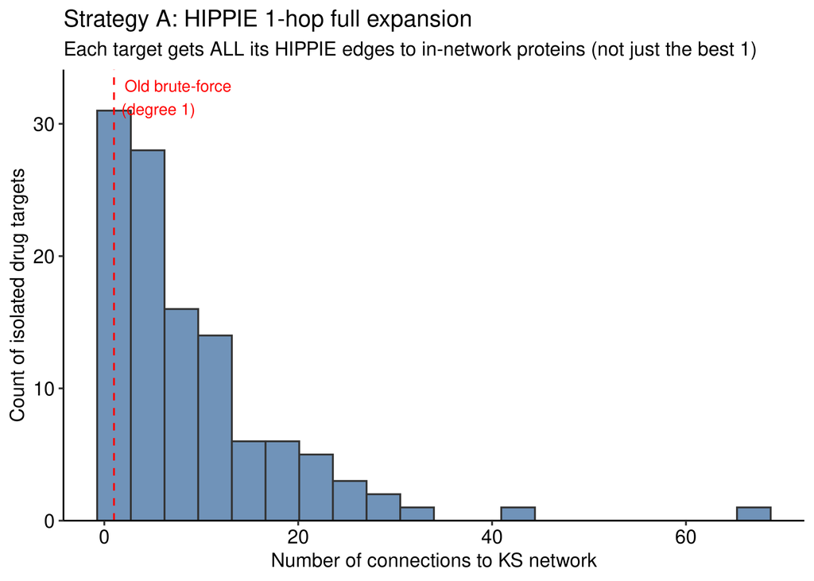

```r
p_strat_a <- ggplot(strat_a_degree, aes(x = degree)) +
  geom_histogram(bins = 20, fill = "#4C78A8", color = "grey20", alpha = 0.8) +
  geom_vline(xintercept = 1, linetype = "dashed", color = "red") +
  annotate("text", x = 1, y = Inf, label = "Old brute-force\n(degree 1)",
           vjust = 1.3, hjust = -0.1, color = "red", size = 3.5) +
  scale_y_continuous(expand = expansion(mult = c(0, 0.1))) +
  labs(x = "Number of connections to KS network",
       y = "Count of isolated drug targets",
       title = "Strategy A: HIPPIE 1-hop full expansion",
       subtitle = "Each target gets ALL its HIPPIE edges to in-network proteins (not just the best 1)") +
  theme_pubr()

p_strat_a
```

# Strategy B: OmniPath Directed Signaling Network

**Rationale:** OmniPath aggregates 85K+ curated directed interactions (from SIGNOR, HPRD, SPIKE, PathwayCommons). This captures biologically meaningful signaling relationships: GPCR → G-protein → kinase activation chains; NR → downstream regulation. These edges represent **causal mechanistic relationships** rather than generic PPIs.

```r
cat("Querying OmniPath directed interactions...\n")
```

```
Querying OmniPath directed interactions...
```

```r
op_net <- omnipath_interactions(organism = 9606, datasets = "omnipath")

cat("Total OmniPath interactions:", nrow(op_net), "\n")
```

```
Total OmniPath interactions: 85217
```

```r
# Filter to directed signaling edges FROM isolated targets TO KS network
op_b <- op_net %>%
  dplyr::filter(source_genesymbol %in% isolated_genes,
                target_genesymbol %in% all_ks_nodes_sym) %>%
  dplyr::filter(is_stimulation | is_inhibition)

cat("\n=== Strategy B: OmniPath directed signaling ===\n\n")
```

```
=== Strategy B: OmniPath directed signaling ===
```

```r
cat("Directed edges (isolated → KS network):", nrow(op_b), "\n")
```

```
Directed edges (isolated → KS network): 177
```

```r
cat("Isolated targets covered: ", n_distinct(op_b$source_genesymbol), "/ 114\n\n")
```

```
Isolated targets covered:  56 / 114
```

```r
# Degree distribution
strat_b_degree <- op_b %>%
  count(source_genesymbol) %>%
  dplyr::rename(gene = source_genesymbol, degree = n)

cat("Degree distribution:\n")
```

```
Degree distribution:
```

```r
summary(strat_b_degree$degree) %>% print()
```

```
   Min. 1st Qu.  Median    Mean 3rd Qu.    Max.
  1.000   1.000   2.000   3.161   5.000   9.000
```

```r
# What relationship types?
cat("\nEdge type breakdown:\n")
```

```
Edge type breakdown:
```

```r
op_b %>%
  dplyr::mutate(type = case_when(
    is_stimulation & !is_inhibition ~ "Stimulation",
    !is_stimulation & is_inhibition ~ "Inhibition",
    is_stimulation & is_inhibition  ~ "Both",
    TRUE ~ "Undirected"
  )) %>%
  count(type) %>% print()
```

```
# A tibble: 2 × 2
  type            n
  <chr>       <int>
1 Inhibition     12
2 Stimulation   165
```

```r
# Sources breakdown
cat("\nTop supporting databases:\n")
```

```
Top supporting databases:
```

```r
op_b %>% separate_rows(sources, sep = ";") %>% count(sources, sort = TRUE) %>% head(10) %>% print()
```

```
# A tibble: 10 × 2
   sources          n
   <chr>        <int>
 1 SIGNOR         151
 2 HINT            48
 3 Wang            45
 4 HPRD            43
 5 SignaLink3      26
 6 SPIKE_LC        24
 7 Lit-BM-17       13
 8 KEGG-MEDICUS     9
 9 SPIKE            9
10 CA1              8
```

```r
cat("Sample OmniPath directed signaling edges:\n")
```

```
Sample OmniPath directed signaling edges:
```

```r
op_b %>%
  dplyr::select(source_genesymbol, target_genesymbol,
                is_stimulation, is_inhibition, sources) %>%
  head(30) %>% print()
```

```
# A tibble: 30 × 5
   source_genesymbol target_genesymbol is_stimulation is_inhibition sources
   <chr>             <chr>             <lgl>          <lgl>         <chr>
 1 CNR1              TRPV1             FALSE          TRUE          TRIP
 2 HTR1B             TRPM8             TRUE           FALSE         TRIP
 3 NR1D2             BMAL1             FALSE          TRUE          SPIKE_LC;SP…
 4 MTNR1A            GNAQ              TRUE           FALSE         SPIKE_LC;SP…
 5 MTNR1A            GNAI2             TRUE           FALSE         HPRD;Baccin…
 6 MTNR1A            MAPK1             TRUE           FALSE         SPIKE_LC;SP…
 7 RXRG              THRB              TRUE           FALSE         HPRD;SignaL…
 8 PSMC3             CDKN2A            TRUE           FALSE         HPRD;SPIKE_…
 9 PSMC3             CDKN2A            TRUE           FALSE         HPRD;SPIKE_…
10 STK36             GLI1              TRUE           FALSE         Wang;NetPat…
# ℹ 20 more rows
```

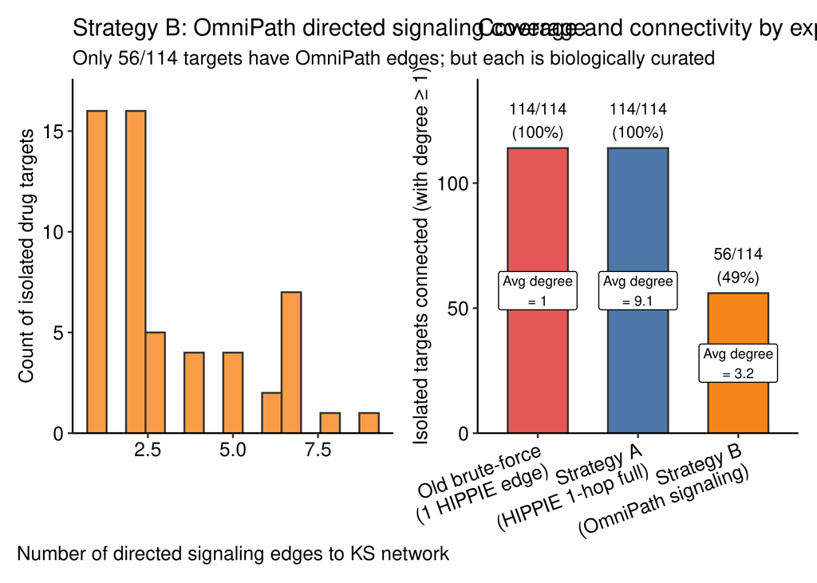

```r
# Degree distribution for strategy B
p_strat_b_degree <- ggplot(strat_b_degree, aes(x = degree)) +
  geom_histogram(bins = 15, fill = "#F58518", color = "grey20", alpha = 0.8) +
  scale_y_continuous(expand = expansion(mult = c(0, 0.1))) +
  labs(x = "Number of directed signaling edges to KS network",
       y = "Count of isolated drug targets",
       title = "Strategy B: OmniPath directed signaling coverage",
       subtitle = "Only 56/114 targets have OmniPath edges; but each is biologically curated") +
  theme_pubr()

# Coverage comparison A vs B
coverage_compare <- tibble(
  strategy = c("Old brute-force\n(1 HIPPIE edge)",
               "Strategy A\n(HIPPIE 1-hop full)",
               "Strategy B\n(OmniPath signaling)"),
  targets_covered = c(114, n_distinct(hippie_a$isolated_node), n_distinct(op_b$source_genesymbol)),
  mean_degree = c(1.0,
                  mean(strat_a_degree$degree),
                  mean(strat_b_degree$degree))
)

p_coverage <- coverage_compare %>%
  ggplot(aes(x = strategy, y = targets_covered, fill = strategy)) +
  geom_col(color = "grey20", width = 0.6, show.legend = FALSE) +
  geom_text(aes(label = paste0(targets_covered, "/114\n(",
                               round(100*targets_covered/114, 0), "%)")),
            vjust = -0.3, size = 3.5) +
  geom_label(aes(y = targets_covered/2,
                 label = paste0("Avg degree\n= ", round(mean_degree, 1))),
             fill = "white", size = 3, label.size = 0.3) +
  scale_fill_manual(values = c(
    "Old brute-force\n(1 HIPPIE edge)" = "#E45756",
    "Strategy A\n(HIPPIE 1-hop full)" = "#4C78A8",
    "Strategy B\n(OmniPath signaling)" = "#F58518"
  )) +
  scale_y_continuous(limits = c(0, 135), expand = expansion(mult = c(0, 0.05))) +
  labs(x = NULL, y = "Isolated targets connected (with degree ≥ 1)",
       title = "Coverage and connectivity by expansion strategy") +
  theme_pubr(x.text.angle = 20)

p_strat_b_degree + p_coverage
```

# Strategy C: OmniPath First, HIPPIE Fallback

```r
# Targets covered by OmniPath
op_covered <- unique(op_b$source_genesymbol)

# Targets NOT covered by OmniPath → get HIPPIE 1-hop
remaining_iso_genes   <- setdiff(isolated_genes, op_covered)
remaining_iso_entrez  <- isolated_entrez[
  isolated_genes[match(isolated_entrez, isolated_genes)] %in% remaining_iso_genes
]

# More directly: get entrez IDs of OmniPath-uncovered targets
op_uncovered_genes   <- setdiff(isolated_genes, op_covered)
op_uncovered_entrez  <- hippie_dt_old %>%
  dplyr::filter(Protein2 %in% op_uncovered_genes) %>%
  pull(Protein2_entrez) %>% unique()

hippie_c <- hippie_hc %>%
  dplyr::filter(
    (Entrez1 %in% op_uncovered_entrez & Entrez2 %in% all_ks_nodes_entrez) |
    (Entrez2 %in% op_uncovered_entrez & Entrez1 %in% all_ks_nodes_entrez)
  ) %>%
  dplyr::mutate(
    iso_entrez = if_else(Entrez1 %in% op_uncovered_entrez, Entrez1, Entrez2),
    iso_gene   = if_else(Entrez1 %in% op_uncovered_entrez, Gene1, Gene2),
    ks_entrez  = if_else(Entrez1 %in% op_uncovered_entrez, Entrez2, Entrez1),
    ks_gene    = if_else(Entrez1 %in% op_uncovered_entrez, Gene2, Gene1)
  ) %>%
  distinct(iso_entrez, iso_gene, ks_entrez, ks_gene, Score)

cat("=== Strategy C: OmniPath + HIPPIE fallback ===\n\n")
```

```
=== Strategy C: OmniPath + HIPPIE fallback ===
```

```r
cat("Phase 1 - OmniPath signaling:\n")
```

```
Phase 1 - OmniPath signaling:
```

```r
cat("  Targets covered: ", length(op_covered), "/ 114\n")
```

```
  Targets covered:  56 / 114
```

```r
cat("  Edges:           ", nrow(op_b), "\n\n")
```

```
  Edges:            177
```

```r
cat("Phase 2 - HIPPIE 1-hop for remaining", length(op_uncovered_genes), "targets:\n")
```

```
Phase 2 - HIPPIE 1-hop for remaining 58 targets:
```

```r
cat("  Targets covered: ", n_distinct(hippie_c$iso_gene), "/", length(op_uncovered_genes), "\n")
```

```
  Targets covered:  58 / 58
```

```r
cat("  Edges:           ", nrow(hippie_c), "\n\n")
```

```
  Edges:            534
```

```r
total_covered_c <- length(op_covered) + n_distinct(hippie_c$iso_gene)
total_edges_c   <- nrow(op_b) + nrow(hippie_c)

cat("TOTAL Strategy C:\n")
```

```
TOTAL Strategy C:
```

```r
cat("  Targets connected: ", total_covered_c, "/ 114\n")
```

```
  Targets connected:  114 / 114
```

```r
cat("  Total edges added: ", total_edges_c, "\n\n")
```

```
  Total edges added:  711
```

```r
# Degree for HIPPIE fallback portion
strat_c_hippie_degree <- hippie_c %>%
  count(iso_gene) %>% dplyr::rename(degree = n)

cat("HIPPIE fallback degree distribution:\n")
```

```
HIPPIE fallback degree distribution:
```

```r
summary(strat_c_hippie_degree$degree) %>% print()
```

```
   Min. 1st Qu.  Median    Mean 3rd Qu.    Max.
  1.000   3.000   7.000   9.207  13.000  42.000
```

```r
cat("\nTargets still completely unreachable after Strategy C:\n")
```

```
Targets still completely unreachable after Strategy C:
```

```r
uncovered_by_c <- setdiff(isolated_genes, c(op_covered, unique(hippie_c$iso_gene)))
cat(length(uncovered_by_c), "targets:", paste(uncovered_by_c, collapse=", "), "\n")
```

```
58 targets: ACTR3, CDC42BPG, FPR2, ACAD10, ACAD11, MUSK, STK32A, CMPK1, DSTYK, DCLK3, AGK, GALK1, TUBB6, SRPK3, GTPBP4, MTHFD1, MTREX, DCTPP1, S1PR4, COX5A, ADCK1, VIPR1, NQO2, NNT, ANKK1, STK35, ESRRB, HSP90AB2P, MYO3B, GARS1, INSRR, IPO7, ABCD3, PI4KA, MAT2A, OPA1, PTH2R, NME2P1, AK2, GSPT1, HSPE1…
```

# Head-to-Head Comparison

```r
# Build comparison table
strat_a_stats <- strat_a_degree %>%
  summarise(
    covered = n(),
    edges = nrow(hippie_a),
    mean_degree = round(mean(degree), 1),
    pct_multi_connected = round(100 * mean(degree >= 2), 1)
  )

strat_b_stats <- strat_b_degree %>%
  summarise(
    covered = n(),
    edges = nrow(op_b),
    mean_degree = round(mean(degree), 1),
    pct_multi_connected = round(100 * mean(degree >= 2), 1)
  )

strat_c_stats <- tibble(
  covered = total_covered_c,
  edges = total_edges_c,
  mean_degree = round((sum(strat_b_degree$degree) + sum(strat_c_hippie_degree$degree)) / total_covered_c, 1),
  pct_multi_connected = round(100 * (sum(strat_b_degree$degree >= 2) + sum(strat_c_hippie_degree$degree >= 2)) / total_covered_c, 1)
)

comparison_df <- bind_rows(
  tibble(strategy = "Old brute-force", covered = 114, edges = 114, mean_degree = 1.0, pct_multi_connected = 0),
  tibble(strategy = "A: HIPPIE 1-hop full", covered = strat_a_stats$covered, edges = strat_a_stats$edges,
         mean_degree = strat_a_stats$mean_degree, pct_multi_connected = strat_a_stats$pct_multi_connected),
  tibble(strategy = "B: OmniPath signaling", covered = strat_b_stats$covered, edges = strat_b_stats$edges,
         mean_degree = strat_b_stats$mean_degree, pct_multi_connected = strat_b_stats$pct_multi_connected),
  tibble(strategy = "C: OmniPath + HIPPIE fallback", covered = strat_c_stats$covered,
         edges = strat_c_stats$edges, mean_degree = strat_c_stats$mean_degree,
         pct_multi_connected = strat_c_stats$pct_multi_connected)
) %>%
  dplyr::mutate(
    pct_covered = round(100 * covered / 114, 1),
    edge_quality = c("PPI (single)", "PPI (multi)", "Curated signaling", "Curated + PPI"),
    overall_drug_coverage = round(
      100 * (sum(drug_targets$target_entrez_id %in% all_ks_nodes_entrez) + covered) / nrow(drug_targets), 1
    )
  )

cat("=== HEAD-TO-HEAD STRATEGY COMPARISON ===\n\n")
```

```
=== HEAD-TO-HEAD STRATEGY COMPARISON ===
```

```r
comparison_df %>%
  dplyr::select(strategy, covered, pct_covered, edges, mean_degree, pct_multi_connected, edge_quality, overall_drug_coverage) %>%
  print()
```

```
# A tibble: 4 × 8
  strategy             covered pct_covered edges mean_degree pct_multi_connected
  <chr>                  <dbl>       <dbl> <dbl>       <dbl>               <dbl>
1 Old brute-force          114       100     114         1                   0
2 A: HIPPIE 1-hop full     114       100    1039         9.1                86
3 B: OmniPath signali…      56        49.1   177         3.2                71.4
4 C: OmniPath + HIPPI…     114       100     711         6.2                80.7
# ℹ 2 more variables: edge_quality <chr>, overall_drug_coverage <dbl>
```

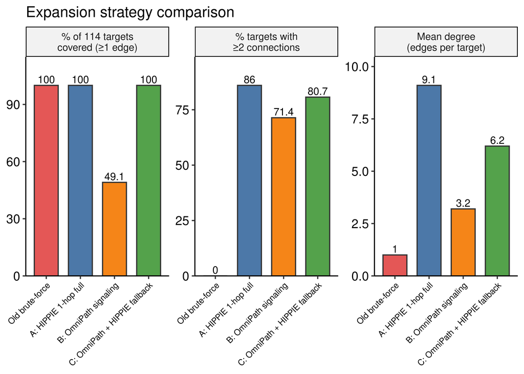

```r
comparison_long <- comparison_df %>%
  dplyr::select(strategy, pct_covered, mean_degree, pct_multi_connected) %>%
  pivot_longer(-strategy, names_to = "metric", values_to = "value") %>%
  dplyr::mutate(
    metric_label = case_when(
      metric == "pct_covered"        ~ "% of 114 targets\ncovered (≥1 edge)",
      metric == "mean_degree"        ~ "Mean degree\n(edges per target)",
      metric == "pct_multi_connected" ~ "% targets with\n≥2 connections"
    ),
    strategy = fct_inorder(strategy)
  )

ggplot(comparison_long, aes(x = strategy, y = value, fill = strategy)) +
  geom_col(color = "grey20", width = 0.7, show.legend = FALSE) +
  geom_text(aes(label = round(value, 1)), vjust = -0.3, size = 3.5) +
  scale_fill_manual(values = c(
    "Old brute-force" = "#E45756",
    "A: HIPPIE 1-hop full" = "#4C78A8",
    "B: OmniPath signaling" = "#F58518",
    "C: OmniPath + HIPPIE fallback" = "#54A24B"
  )) +
  scale_y_continuous(expand = expansion(mult = c(0, 0.15))) +
  facet_wrap(~metric_label, scales = "free_y", nrow = 1) +
  labs(x = NULL, y = NULL, title = "Expansion strategy comparison") +
  theme_pubr(x.text.angle = 45) +
  theme(axis.text.x = element_text(size = 8))
```

# What Do the OmniPath Connections Look Like?

The OmniPath directed edges are qualitatively different from PPIs. They represent curated signaling relationships from databases like SIGNOR, HPRD, and SPIKE.

```r
# Annotate with functional category
op_b_annotated <- op_b %>%
  left_join(target_class %>% dplyr::select(SYMBOL, category),
            by = c("source_genesymbol" = "SYMBOL")) %>%
  dplyr::mutate(
    edge_type = case_when(
      is_stimulation & !is_inhibition ~ "Activates",
      !is_stimulation & is_inhibition ~ "Inhibits",
      is_stimulation & is_inhibition  ~ "Dual effect",
      TRUE ~ "Undirected"
    )
  )

cat("OmniPath edges by target category and edge type:\n")
```

```
OmniPath edges by target category and edge type:
```

```r
op_b_annotated %>%
  count(category, edge_type) %>%
  pivot_wider(names_from = edge_type, values_from = n, values_fill = 0) %>%
  print()
```

```
# A tibble: 6 × 3
  category            Activates Inhibits
  <chr>                   <int>    <int>
1 GPCR                       51        1
2 Kinase/Kinase-like          6        6
3 Metabolic Enzyme            2        2
4 Nuclear Receptor           20        2
5 Other                      83        1
6 Transporter/Channel         3        0
```

```r
# Show some GPCR → kinase examples
cat("\nGPCR signaling to KS network nodes (sample):\n")
```

```
GPCR signaling to KS network nodes (sample):
```

```r
op_b_annotated %>%
  dplyr::filter(category == "GPCR") %>%
  dplyr::select(source_genesymbol, target_genesymbol, edge_type, sources) %>%
  distinct() %>%
  head(20) %>%
  print()
```

```
# A tibble: 20 × 4
   source_genesymbol target_genesymbol edge_type sources
   <chr>             <chr>             <chr>     <chr>
 1 CNR1              TRPV1             Inhibits  TRIP
 2 MTNR1A            GNAQ              Activates SPIKE_LC;SPIKE
 3 MTNR1A            GNAI2             Activates HPRD;Baccin2019;Ramilowski2015…
 4 MTNR1A            MAPK1             Activates SPIKE_LC;SPIKE
 5 DRD1              GNAS              Activates KEGG-MEDICUS;SIGNOR;HINT;CA1;W…
 6 CHRM4             EEF1A2            Activates Wang;HPRD;Cui2007;CA1
 7 DRD3              GRB2              Activates Wang;HPRD;Cui2007;CA1
 8 CNR1              HCRTR1            Activates HPRD;SIGNOR
 9 P2RY1             GNA13             Activates SIGNOR
10 P2RY1             GNAS              Activates SIGNOR
11 CHRM3             GNAI1             Activates SIGNOR
12 P2RY1             GNAI1             Activates SIGNOR
13 DRD3              GNAI1             Activates HPRD;HINT;SIGNOR
14 DRD3              GNAZ              Activates SIGNOR
15 ADORA1            GNAZ              Activates HPRD;SPIKE_LC;SIGNOR
16 CHRM3             GNAQ              Activates KEGG-MEDICUS;HPRD;Wang;SIGNOR
17 DRD1              GNAI1             Activates SIGNOR
18 P2RY12            GNAI1             Activates SIGNOR
19 MTNR1A            GNAI1             Activates HPRD;HINT;SIGNOR;SPIKE_LC
20 MTNR1B            GNAI1             Activates HPRD;HINT;SIGNOR;SPIKE_LC
```

```r
cat("\nNuclear receptor → KS network (all):\n")
```

```
Nuclear receptor → KS network (all):
```

```r
op_b_annotated %>%
  dplyr::filter(category == "Nuclear Receptor") %>%
  dplyr::select(source_genesymbol, target_genesymbol, edge_type, sources) %>%
  distinct() %>%
  print()
```

```
# A tibble: 22 × 4
   source_genesymbol target_genesymbol edge_type sources
   <chr>             <chr>             <chr>     <chr>
 1 NR1D2             BMAL1             Inhibits  SPIKE_LC;SPIKE
 2 RXRG              THRB              Activates HPRD;SignaLink3
 3 RARB              RARG              Activates SPIKE_LC;SPIKE
 4 RXRG              RARA              Activates Wang;HPRD;HINT;HuRI;SignaLink3…
 5 RARB              RXRA              Activates Wang;InnateDB_SignaLink3;SIGNO…
 6 RXRB              RARA              Activates Wang;SIGNOR;HPRD;HINT;HuRI;Sig…
 7 RXRB              RARG              Activates Wang;SIGNOR;HPRD;HINT;HuRI;Sig…
 8 RXRB              PPARG             Activates SIGNOR;HPRD;SignaLink3;IntAct;…
 9 RXRG              PPARG             Activates Wang;HPRD;SPIKE_LC;SignaLink3
10 RXRB              VDR               Activates HPRD;Lit-BM-17;SignaLink3
# ℹ 12 more rows
```